# Pygmy Rockfish

*Sebastes wilsoni*

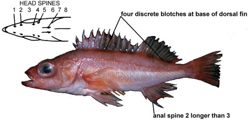

**Body color:** Light brown, flushed w/ red; about 4 dark blotches along base of dorsal fin; a brownish-red stripe below lateral line.

**Peritoneum color:** dark **Shape between eyes:** flat

**Counts:** D:XIII,13-15, Ar:5-7, P1:16-18, GR:37-43, LLp:37-46, LLs:45-50, V:27-28

**Occurence:** Gulf of Alaska - Southern California

**Depth:** 30-274 meters **Size:** 23 cm **Species code:** 30550

**Similar species:**

- *Puget Sound rockfish* - body color differs, brownish-red stripe absent below lateral line; anal rays typically 7 (typically 6 in Pygmy RF)
- *Shortbelly rockfish* - anus about midway between anal-fin origin and pelvic-fin base (immediately in front of anal fin in Pygmy RF); anal spine 2 shorter than 3; head spines weaker
- *Sharpchin rockfish* - dorsal blotches extend below lateral line; symphyseal knob sharp and prominent; strong dark stripes extend posterior to eye
- *Pacific Ocean Perch* - symphyseal knob sharp, elongate; head spines weak and count differs; anal spine 2 shorter than 3

Back to Group

**Corrections:** If you see mistakes or want to suggest changes, please create an [issue](https://github.com/zoyafuso-NOAA/RACE_Survey_App/issues) on the source repository or

*reach out to Liz Dawson (Liz.Dawson AT noaa.gov).*